# CEP 11: Data Preparation and Readiness

- Show All Code
- Hide All Code
- View Source

AI-Assisted Evidence Synthesis for Personalization in Marketing Communication

Authors

Yushan Huang

Simran Kaur

Gabriela Raygoza Quintero

Alondra Rodriguez

Published

November 23, 2026

## Purpose and scope

This report documents data readiness for the CEP’s AI-assisted meta-analysis. The project uses the publicly available replication data for *Personalization in Marketing Communication: A Meta-Analysis* (Eisend, Niewiadomska, and van Noort, 2026), together with source-paper evidence and separately stored AI coding outputs.

This is not a GA4 project, and the main data set is not a survey. The analytic unit is an effect-size record from a published study, so preparation focuses on record identity, source provenance, effect-size fields, outcome classifications, moderators, missingness, duplicates, and reproducibility of the published analysis. The one survey in the replication packet (the authors’ manager survey) is prepared in the AO4 section because it feeds the consultant playbook.

The raw human-coded replication data are the benchmark. They must remain unchanged. AI-generated values and labels are stored in separate candidate files and joined only through documented record identifiers.

### Folder setup

The report reads the files from the repo’s `dataverse_files` folder. It finds that folder whether chunks are run from the repo root or the report is rendered from its own folder. To use a different location, set `data_root` in the YAML to that folder’s path. Do not move, overwrite, or redistribute the original files, and keep `dataverse_files/` in `.gitignore`.

```
CEP--Group-8/
  dataverse_files/                     # Dataverse replication packet (not pushed)
    personalization.sav
    personalizationcorrelation.sav     # needed for the last part of the integration script
    manager-survey.sav
    personalization-integration.R
    personalization-metareg.R
  CEP11-Data-Preparation/
    CEP11-Data-Preparation.qmd
  data/derived/
    ai_numeric_candidates.csv          # created later by AO1
    ai_outcome_candidates.csv          # created later by AO2
```

## Data sources and governance

| Data asset | Role in the CEP | Handling rule |
| --- | --- | --- |
| `personalization.sav` | Human-coded effect-size benchmark and AO3 baseline | Preserve as read-only; do not overwrite values or labels. |
| Original R scripts | Published-analysis specification and reproduction reference | Copy locally and run unchanged before creating any AI substitution version. |
| `manager-survey.sav` | Manager ratings of the paper’s key findings; input to the AO4 playbook | Drop personal and device fields before any analysis or sharing. |
| Source articles and excerpts | Evidence used to validate coding decisions | Retain page/table references; do not post or redistribute course-only files. |
| AI numeric candidate file | AO1 output | Store separately, with record ID, source page, model/version, prompt version, and human-review status. |
| AI outcome candidate file | AO2 output | Store separately, with record ID, source page, model/version, prompt version, and human-review status. |

No value should be imputed merely because a field is missing. A value that is absent from a source paper stays `not reported` or `NA`; it is never coded as zero.

```r
library(haven)
library(dplyr)
library(tidyr)
library(tibble)
library(knitr)
library(ggplot2)

`%||%` <- function(x, y) if (is.null(x) || length(x) == 0) y else x

# params only exists when rendering; in the console fall back to "auto"
root_setting <- if (exists("params")) params$data_root else "auto"
data_root <- if (root_setting != "auto") root_setting else
  if (dir.exists("dataverse_files")) "dataverse_files" else "../dataverse_files"
out_dir <- if (dir.exists("CEP11-Data-Preparation")) "CEP11-Data-Preparation" else "."

raw_file <- file.path(data_root, "personalization.sav")
metareg_script <- file.path(data_root, "personalization-metareg.R")
integration_script <- file.path(data_root, "personalization-integration.R")
correlation_file <- file.path(data_root, "personalizationcorrelation.sav")
survey_file <- file.path(data_root, "manager-survey.sav")

# Chart colors (checked for color-vision deficiency) and a quiet theme
green <- "#2F7D4A"; gold <- "#B7861A"; muted <- "#C9CDD2"
theme_cep <- theme_minimal(base_size = 13) +
  theme(panel.grid.minor = element_blank(), panel.grid.major.y = element_blank(),
        panel.grid.major.x = element_line(color = "#ECEEF0"), plot.title.position = "plot",
        axis.title = element_text(color = "#5f6368"), strip.text = element_text(face = "bold", hjust = 0))
```

```r
tibble(
  source = c("Human-coded SPSS benchmark", "Original meta-regression script",
             "Original integration script", "Correlation data set (integration-script appendix)",
             "Manager survey"),
  file = basename(c(raw_file, metareg_script, integration_script, correlation_file, survey_file)),
  available = file.exists(c(raw_file, metareg_script, integration_script, correlation_file, survey_file))
) |> kable(caption = "Required Source Files")
```

Required Source Files

| source | file | available |
| --- | --- | --- |
| Human-coded SPSS benchmark | personalization.sav | TRUE |
| Original meta-regression script | personalization-metareg.R | TRUE |
| Original integration script | personalization-integration.R | TRUE |
| Correlation data set (integration-script appendix) | personalizationcorrelation.sav | TRUE |
| Manager survey | manager-survey.sav | TRUE |

## Data-readiness checks

These checks are the meta-analysis equivalent of the GA4 integrity checklist. They establish whether the benchmark data can support the four analytics objectives before AI candidate values are substituted.

| Readiness question | Check in this report |
| --- | --- |
| Can the team access and preserve the benchmark? | Source files present (above). |
| Is the coverage sufficient? | Row counts, and the filtered sample against the published counts. |
| Are required fields available and complete? | Variable dictionary with missingness for the key fields. |
| Can records be matched safely? | Stable, unique effect-record ID. |
| Do values make research sense? | Valid ranges for effect sizes and sample sizes. |
| Is the human coding reliable? | Agreement between coders 1 and 2. |
| Can the published analysis be reproduced? | AO3 protocol (run the original scripts unchanged). |

### Benchmark overview and record identity

```r
human_raw <- read_sav(raw_file)
human <- as_tibble(human_raw)

if (anyDuplicated(human$IDES)) stop("IDES must be unique before it is used as the effect-record key.")

tibble(measure = c("Rows", "Columns", "Full-row duplicates", "Duplicate IDES values"),
       value = c(nrow(human), ncol(human), sum(duplicated(human)), sum(duplicated(human$IDES)))) |>
  kable(caption = "Human-Coded Benchmark Overview")
```

Human-Coded Benchmark Overview

| measure | value |
| --- | --- |
| Rows | 2452 |
| Columns | 237 |
| Full-row duplicates | 0 |
| Duplicate IDES values | 0 |

```r
key_fields <- c("IDES", "IDD", "IDP", "ESW", "VAR", "ES_RAW", "VAR_RAW", "SAMPLE", "DV",
                "DVcoder1", "DVcoder2", "exclude", "YEAR")
tibble(
  field = key_fields,
  label = vapply(human_raw[key_fields], function(x) attr(x, "label") %||% "(no label)", character(1)),
  missing_n = vapply(human[key_fields], function(x) sum(is.na(x)), numeric(1)),
  distinct = vapply(human[key_fields], function(x) n_distinct(x, na.rm = TRUE), numeric(1))
) |> kable(caption = "Key-Field Dictionary and Missingness (All 2,452 Rows)")
```

Key-Field Dictionary and Missingness (All 2,452 Rows)

| field | label | missing_n | distinct |
| --- | --- | --- | --- |
| IDES | ID effect size | 0 | 2452 |
| IDD | ID data set | 0 | 407 |
| IDP | ID paper | 0 | 309 |
| ESW | (no label) | 633 | 1787 |
| VAR | (no label) | 650 | 1787 |
| ES_RAW | (no label) | 525 | 1572 |
| VAR_RAW | (no label) | 542 | 1848 |
| SAMPLE | (no label) | 232 | 377 |
| DV | dependent/second variable categories | 276 | 44 |
| DVcoder1 | dependent/second variable categories | 8 | 44 |
| DVcoder2 | dependent/second variable categories | 740 | 42 |
| exclude | exclude final including 2nd round of coding | 0 | 5 |
| YEAR | publication year | 0 | 22 |

`IDES` is unique across all 2,452 rows, so it is the join key for every AI candidate file. Missing values in `ESW`, `VAR`, and `DV` sit entirely in excluded rows, which the next check confirms. The full 237-variable dictionary is in the collapsed block below.

**NoteFull variable dictionary (237 variables)**

```r
tibble(
  variable = names(human_raw),
  label = vapply(human_raw, function(x) paste(attr(x, "label") %||% "", collapse = " "), character(1)),
  missing_pct = round(100 * vapply(human_raw, function(x) mean(is.na(x)), numeric(1)), 1)
) |> kable()
```

| variable | label | missing_pct |
| --- | --- | --- |
| IDES | ID effect size | 0.0 |
| IDD | ID data set | 0.0 |
| IDP | ID paper | 0.0 |
| exclude | exclude final including 2nd round of coding | 0.0 |
| ESW |  | 25.8 |
| VAR |  | 26.5 |
| SAMPLE |  | 9.5 |
| ES_RAW |  | 21.4 |
| VAR_RAW |  | 22.1 |
| ESWPERSO | es of personalization manipulation check/measure | 77.1 |
| MEANPERSO | mean of personalization scale | 69.4 |
| DV | dependent/second variable categories | 11.3 |
| PERSUASIONSUCCESS | DVS = PERSUASIONSUCCESS | 11.3 |
| ATTITUDESBEHAVIOR | DVS = ATTITUDESBEHAVIOR | 11.3 |
| ATTITUDES | DVS = ATTITUDES | 11.3 |
| BEHAVIORCAT | DVS = BEHAVIORCAT | 11.3 |
| PERSUASIONFAILURE | DVS = PERSUASIONFAILURE | 11.3 |
| DEMOGRAPHIC_LEV2 | demographic data included coder 1 - lev 2 of comparison within ES | 28.1 |
| PSYCHOGRAPHIC_LEV2 | psychographic data included coder 1 - lev 2 of comparison within ES | 28.1 |
| SOCIOECONOMIC_LEV2 | socioeconomic data included coder 1 - lev 2 of comparison within ES | 28.1 |
| GEOGRAPHIC_LEV2 | geographic data included coder 1 - lev 2 of comparison within ES | 28.1 |
| BEHAVIORAL_LEV2 | behavioral data included coder 1 - lev 2 of comparison within ES | 28.1 |
| PERSOIMPL_LEV2 | implicit (vs explicit) use of information (active and explicit indication by user or implicit derivation) - level 2 | 17.8 |
| SERVICE | service vs all else | 22.6 |
| BRANDTYPE_DUMMY | ficticious vs other | 11.8 |
| NONPROFIT | nonprofit vs other context | 32.3 |
| NONCONTRACTUAL | noncontractual nature of advertised product vs other | 32.3 |
| SOCIAL_MEDIA | social media vs other | 11.8 |
| ONLINE | online vs offline/other channel | 32.3 |
| ADPUBLIC | ad displayed publicly vs other | 32.3 |

[output cut: 207 more lines]

### Analysis sample matches the published counts

The published models use only rows with `exclude == 0`. If our filtered data do not match the article, every AO comparison is off from the start.

Figure 1: From 2,452 Coded Rows to the 1,536 Effects in the Published Analysis

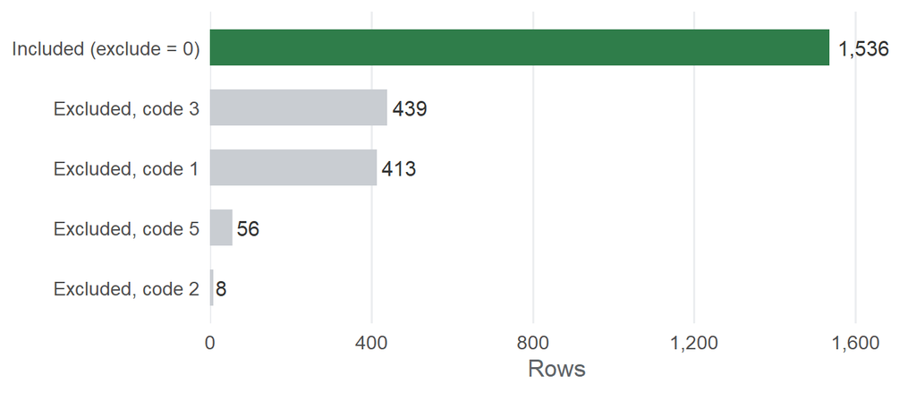

```r
included <- human |> filter(exclude == 0)

human |>
  count(exclude) |>
  mutate(status = if_else(exclude == 0, "Included (exclude = 0)", paste0("Excluded, code ", exclude)),
         status = reorder(status, n)) |>
  ggplot(aes(n, status, fill = exclude == 0)) +
  geom_col(width = 0.6) +
  geom_text(aes(label = scales::comma(n)), hjust = -0.15, size = 4, color = "#333333") +
  scale_fill_manual(values = c(`TRUE` = green, `FALSE` = muted), guide = "none") +
  scale_x_continuous(expand = expansion(mult = c(0, 0.12)), labels = scales::comma) +
  labs(x = "Rows", y = NULL) + theme_cep
```

```r
tibble(measure = c("Effect sizes", "Studies (IDD)", "Papers (IDP)"),
       published = c(1536, 290, 229),
       our_data = c(nrow(included), n_distinct(included$IDD), n_distinct(included$IDP))) |>
  mutate(difference = our_data - published) |>
  kable(caption = "Filtered Data vs. Counts Reported in Eisend et al. (2026)")
```

Filtered Data vs. Counts Reported in Eisend et al. (2026)

| measure | published | our_data | difference |
| --- | --- | --- | --- |
| Effect sizes | 1536 | 1536 | 0 |
| Studies (IDD) | 290 | 289 | -1 |
| Papers (IDP) | 229 | 223 | -6 |

```r
included |>
  summarise(missing_ESW = sum(is.na(ESW)), missing_VAR = sum(is.na(VAR)), missing_DV = sum(is.na(DV)),
            r_outside_minus1_to_1 = sum(abs(ES_RAW) > 1, na.rm = TRUE),
            sample_below_10 = sum(SAMPLE < 10, na.rm = TRUE)) |>
  kable(caption = "Completeness and Range Checks, Included Effects")
```

Completeness and Range Checks, Included Effects

| missing_ESW | missing_VAR | missing_DV | r_outside_minus1_to_1 | sample_below_10 |
| --- | --- | --- | --- | --- |
| 0 | 0 | 0 | 0 | 0 |

The effect-size count matches exactly, and the included rows have no missing effect sizes, variances, or outcome codes and no impossible correlations. The study and paper counts are slightly lower than the article (289 vs. 290 and 223 vs. 229). The likely cause is IDs merged or renumbered after the article’s counts were set, but the file can’t confirm it, so this goes to Dr. Lin before the AO baselines.

### Outcome families and effect-size ranges

The authors group the 44 outcome codes into broad families in `personalization-integration.R`. We add the category names to `DV` and recode it into a new `dv_family` variable using the same code lists, leaving `DV` untouched. The recode reproduces the authors’ own `PERSUASIONSUCCESS` and `PERSUASIONFAILURE` flags row for row.

Figure 2: Uncorrected Effect Sizes (r) by Outcome Family, Included Effects

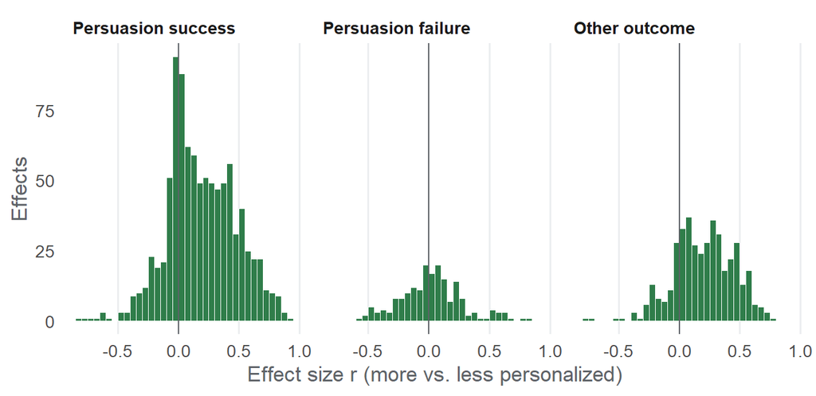

```r
success_codes <- c(1, 3, 4, 5, 7, 30, 31, 8, 13, 16, 26, 35, 39, 41, 42)
failure_codes <- c(9, 12, 14, 24, 29, 38)

included <- included |>
  mutate(DV = labelled(as.numeric(DV), attr(human_raw$DVcoder1, "labels")),
         dv_family = factor(case_when(as.numeric(DV) %in% success_codes ~ "Persuasion success",
                                      as.numeric(DV) %in% failure_codes ~ "Persuasion failure",
                                      TRUE ~ "Other outcome"),
                            levels = c("Persuasion success", "Persuasion failure", "Other outcome")))

stopifnot(all((included$dv_family == "Persuasion success") == (included$PERSUASIONSUCCESS == 1)),
          all((included$dv_family == "Persuasion failure") == (included$PERSUASIONFAILURE == 1)))

ggplot(included, aes(ES_RAW)) +
  geom_histogram(binwidth = 0.05, boundary = 0, fill = green, color = "white", linewidth = 0.3) +
  geom_vline(xintercept = 0, color = "#5f6368", linewidth = 0.4) +
  facet_wrap(~ dv_family, nrow = 1) +
  labs(x = "Effect size r (more vs. less personalized)", y = "Effects") + theme_cep
```

Success outcomes lean positive (937 effects) and failure outcomes sit close to zero (188 effects), which is the shape the article reports.

### Reliability of the human coding

In a meta-analysis the codebook is the measurement instrument, so reliability means agreement between independent coders. We check coder 1 against coder 2 with Cohen’s kappa, the same comparison AO2 will run for the AI coders.

```r
kappa_row <- function(a, b, name) {
  x <- included |> select(all_of(c(a, b))) |> mutate(across(everything(), as.numeric)) |> drop_na()
  tibble(code = name, rows_both_coded = nrow(x),
         percent_agree = round(100 * mean(x[[1]] == x[[2]]), 1),
         cohens_kappa = round(psych::cohen.kappa(as.matrix(x))$kappa, 3))
}

bind_rows(
  kappa_row("DVcoder1", "DVcoder2", "Outcome category (44 codes)"),
  kappa_row("demographic1", "demographic2", "Demographic data used"),
  kappa_row("psychographic1", "psychographic2", "Psychographic data used"),
  kappa_row("socioeconomic1", "socioeconomic2", "Socioeconomic data used"),
  kappa_row("geographic1", "geographic2", "Geographic data used"),
  kappa_row("behavioral1", "behavioral2", "Behavioral data used")
) |> kable(caption = "Inter-Coder Reliability, Coder 1 vs. Coder 2 (Included Effects)")
```

Inter-Coder Reliability, Coder 1 vs. Coder 2 (Included Effects)

| code | rows_both_coded | percent_agree | cohens_kappa |
| --- | --- | --- | --- |
| Outcome category (44 codes) | 1203 | 86.5 | 0.857 |
| Demographic data used | 1173 | 90.2 | 0.791 |
| Psychographic data used | 1173 | 89.9 | 0.784 |
| Socioeconomic data used | 1165 | 96.8 | 0.742 |
| Geographic data used | 1165 | 96.5 | 0.797 |
| Behavioral data used | 1173 | 94.7 | 0.871 |

The outcome-category kappa is .857, the same value the article reports, so the prepared data reproduce the authors’ reliability check. Every code clears the usual .61 bar for substantial agreement (Landis and Koch 1977).

Figure 3: Outcome Categories with the Most Coder Disagreement (30+ Rows; Row Count in Parentheses)

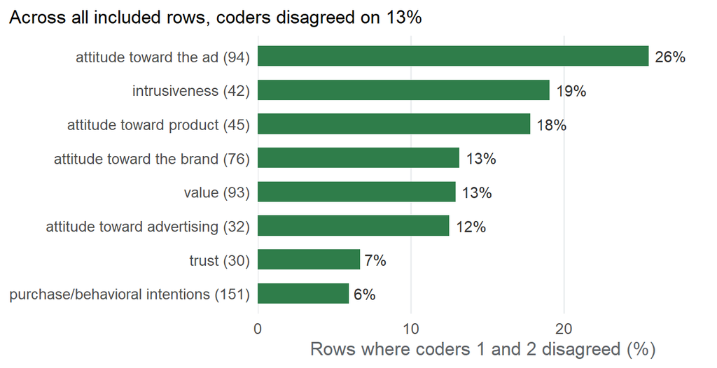

```r
agree <- included |> filter(!is.na(DVcoder1), !is.na(DVcoder2)) |>
  mutate(disagree = as.numeric(DVcoder1) != as.numeric(DVcoder2))

agree |>
  group_by(category = as.character(as_factor(DVcoder1))) |>
  summarise(rows = n(), pct = 100 * mean(disagree)) |>
  filter(rows >= 30) |> slice_max(pct, n = 8) |>
  mutate(category = reorder(paste0(category, " (", rows, ")"), pct)) |>
  ggplot(aes(pct, category)) +
  geom_col(width = 0.6, fill = green) +
  geom_text(aes(label = paste0(round(pct), "%")), hjust = -0.2, size = 3.8, color = "#333333") +
  scale_x_continuous(expand = expansion(mult = c(0, 0.15))) +
  labs(x = "Rows where coders 1 and 2 disagreed (%)", y = NULL,
       subtitle = paste0("Across all included rows, coders disagreed on ", round(100 * mean(agree$disagree)), "%")) +
  theme_cep
```

Attitude toward the ad is the hardest category for human coders, which tells AO2 where AI coding will need the clearest rules.

### Field map for the CEP

| Analytic role | Dataset field | Required for | Rule |
| --- | --- | --- | --- |
| Stable effect-record ID | `IDES` | AO1, AO2, AO3 | Match each AI candidate to exactly one benchmark row. Never join by row order. |
| Paper/article ID | `IDP` | AO1–AO4 | Parent key; one paper can contain multiple studies and effects. AO4 deduplicates new studies against these papers. |
| Data-set/study cluster ID | `IDD` | AO1, AO2, AO3 | Preserve for the published random-effects hierarchy. |
| Human weighted effect-size value | `ESW` | AO1, AO3 | The outcome used by the authors’ multilevel meta-analysis. |
| Effect-size sampling variance | `VAR` | AO1, AO3 | Preserve when rerunning the authors’ multilevel model. |
| Raw effect-size fields | `ES_RAW`, `VAR_RAW` | AO1, AO3 | Keep separately; do not substitute them for `ESW`/`VAR` without the authors’ transformation. |
| Final outcome code | `DV` | AO2, AO3, AO4 | Use for individual outcome categories and recompute broad category flags after an AI-code substitution. |
| Human outcome text / coding history | `V2description`, `DVcoder1`, `DVcoder2`, `DVcoder3`, `DVinconsistencies` | AO2, AO3 | Retain as source and adjudication context; do not overwrite. |
| Final-inclusion status | `exclude` | AO1–AO4 | The published models use `exclude == 0`; retain the original flag. |
| Moderator fields | `DEMOGRAPHIC_LEV2` through `PUBLISHED`, as in the meta-regression script | AO3, AO4 | Use only the published moderator definitions and coding rules. |
| Bibliographic fields | `title`, `authors`, `YEAR` | AO4 | Build the anchor list used to remove duplicates from the update search. |
| Source-paper/page evidence | External evidence log | AO1, AO2, AO3 | Store in the AI candidate file, not by editing the benchmark. |

## AO1. Effect-size extraction accuracy (Alondra)

### AO1 objective and rationale

AO1 will evaluate how accurately AI can extract effect-size information from primary studies on personalization in marketing communication. An effect size describes the direction and magnitude of a finding, such as how much purchase intention differs between consumers who saw a personalized advertisement and those who saw a general advertisement.

One challenge is that a paper may report several findings in the same table. For example, the table may include both brand attitude and purchase intention, measured immediately after exposure and again a week later. An AI coder could copy a value exactly and still select the wrong outcome or time point. AO1 will therefore evaluate both the numerical value and the evidence connecting it to the intended comparison.

### AO1 data structure and preparation rules

The team will use the primary articles as the source for extraction and the human-coded replication dataset from Eisend, Niewiadomska, and van Noort (2026) as the benchmark. Each AI extraction will be linked to the specific effect it represents. The following fields will guide that comparison.

| Dataset field | Purpose in AO1 |
| --- | --- |
| IDP | Identifies the paper where the finding was reported. |
| IDD | Identifies the study or dataset associated with the finding. |
| IDES | Identifies the individual effect and links the AI extraction to its benchmark record. |
| ES_RAW | Provides the human-coded raw effect for comparison when the extracted statistic uses the same measure and scale. |
| ESW | Provides the human-coded effect on the scale used in the published meta-analysis. |

The team will preserve the original human-coded dataset and store AI-generated values separately. This will allow reviewers to trace each comparison back to the article and examine the AI’s original answer after review.

### AO1 numeric extraction log

The extraction log will document what the AI selected, where it found the value, and how that value was prepared for comparison.

| Extraction field | Information recorded |
| --- | --- |
| Target comparison | The outcome, groups being compared, and time point associated with the effect. |
| Reported statistic | The type of statistic and the value as printed, including its sign and decimal places. |
| Source evidence | The printed page and the specific table, row, column, or passage supporting the extraction. |
| Conversion details | The inputs and calculation used when the published analysis requires the statistic to be expressed on a different scale. |
| Model and prompt version | The AI model and extraction instructions used for the record. |
| Review decision | Whether the candidate was accepted, rejected, marked for further review, or recorded as an abstention, along with the reason. |

### AO1 extraction and comparison method

The team will first use a set of development articles to refine the extraction instructions. If the AI repeatedly selects the wrong comparison group, for example, the team can revise the prompt to identify the treatment and comparison groups explicitly. The instructions will then be finalized and applied to a separate set of articles. All effects from the same paper will stay together so the final evaluation uses articles the team has not already used to revise the prompt.

For each target effect, the AI will receive the article and a description of the comparison to locate. It will record the statistic and cite the supporting page or table before the team reveals the human-coded value. The reviewer will then match the extraction to its IDES record and compare the values on the same scale. When a conversion is required, the reviewer will retain the original statistic and document the calculation. This will allow the team to determine whether a discrepancy began with the extraction or arose during conversion.

### AO1 extraction validation and quality checks

1. **Record matching.** Confirm that the cited finding corresponds to the intended study, outcome, groups, and time point.
2. **Source verification.** Check the value against the cited passage or table cell, including its sign, decimal placement, and group order.
3. **Scale alignment.** Verify that the AI-derived value and the benchmark represent the same statistic on the same scale before calculating a difference.
4. **Missing information.** Mark an unreported statistic as missing. If the article supports a raw extraction but omits an input needed for conversion, retain the raw value and document the missing input.
5. **Discrepancy review.** Preserve the AI’s initial answer and record the reviewer’s decision separately. This will allow the team to measure initial accuracy and explain any subsequent corrections.

### AO1 evaluation metrics

- **Extraction coverage.** The percentage of attempted records for which the AI provides a value supported by a source reference.
- **Agreement at reported precision.** The percentage of comparable raw values that match the human benchmark when both are evaluated at the precision printed in the article.
- **Mean absolute error.** The average absolute difference between AI-derived values and human-coded values on the ESW scale. This measure will show how far the estimates typically differ.
- **Direction disagreement.** The percentage of comparable nonzero effects with opposite signs after the reviewer confirms that the groups are ordered consistently.
- **Abstention rate.** The percentage of attempted records for which the AI declines to provide a value. Reviewers will document whether the necessary information was missing or whether the AI overlooked an available result.

## AO2. Outcome construct alignment with CALIPER (Gabriela)

### AO2 objective and rationale

AO2 evaluates whether AI-assisted coding can accurately classify the dependent-variable outcomes reported in primary marketing studies into the outcome categories established by the original meta-analysis. The challenge is that different studies may use different terminology to describe similar constructs, or use the same construct name while measuring different concepts.

The objective is to determine whether CALIPER can improve the alignment between an author’s outcome label, its definition, and its actual measurement, while preserving the original meta-analysis outcome categories and definitions. Only the coding rules used to assign outcomes to those categories may be revised.

### AO2 data structure and preparation rules

AO2 uses the original human-coded SPSS dataset, personalization.sav, as its reference source. The dataset contains 2,452 effect-size records. The original data must remain unchanged throughout the coding and evaluation process.

The primary outcome variable is DV, which contains the final human-adjudicated outcome classification. Supporting fields include:

| Dataset field | Purpose in AO2 |
| --- | --- |
| IDES | Unique effect-size record identifier used to match AI classifications to the human benchmark. |
| IDP | Paper identifier used to retain the connection between outcome records and their original studies. |
| IDD | Study/data-set identifier used to preserve the original record structure. |
| DV | Final human-coded outcome classification and primary evaluation benchmark. |
| V2description | Original outcome description used to understand the construct being measured. |
| DVcoder1 | First human coder’s outcome classification. |
| DVcoder2 | Second human coder’s outcome classification. |
| DVcoder3 | Third human coder’s outcome classification. |
| DVinconsistencies | Documentation of disagreements or inconsistencies in outcome coding. |

The outcome codebook will use the original meta-analysis categories and their definitions from Tables 3 and 5 of the published study. These categories must remain fixed so that AI classifications can be evaluated against the same classification framework used by the human coders.

A separate outcome crosswalk will connect the terminology used in individual studies to the corresponding meta-analysis outcome categories. The crosswalk will document the author’s original construct label, definition, operationalization, measure type, assigned outcome category, and justification for the classification.

### AO2 outcome codebook and crosswalk

The crosswalk will serve as the reference structure for organizing and evaluating outcome classifications. It will distinguish between the terminology used by individual researchers and the standardized outcome categories used in the meta-analysis.

The following information will be documented for each coded outcome:

| Crosswalk field | Description |
| --- | --- |
| Original construct label | Outcome terminology used by the primary study’s authors. |
| Construct definition | Explanation of what the outcome is intended to measure. |
| Operationalization | How the construct was measured, including survey items, scales, or behavioral measures. |
| Measure type | Type of measurement used to capture the outcome. |
| Assigned category | Corresponding outcome category from the original meta-analysis codebook. |
| Classification justification | Explanation of why the outcome was assigned to that category, supported by source evidence. |
| Disagreement type | Whether a disagreement resulted from a coding-rule gap, missing evidence, or a genuine difference in construct interpretation. |

The crosswalk will be developed using the original outcome classifications and supporting primary-study evidence. Any proposed changes to coding rules will be documented in a rule-change log. These revisions will be developed using the development articles and frozen before the test-set evaluation to prevent changes to the coding framework based on test results.

### AO2 classification comparison and CALIPER method

AO2 will evaluate four coding conditions to determine how access to article information, standardized category definitions, and CALIPER-assisted rule revisions influence AI classification accuracy.

| Condition | Information provided to AI | Purpose |
| --- | --- | --- |
| 0. Label-only | Original outcome wording and codebook, without article text. | Establish baseline classification performance using outcome labels alone. |
| A. Article and categories | Primary-study article and meta-analysis category names. | Evaluate classification using article evidence without the full coding rules. |
| B. Single AI coder | Primary-study article and original codebook. | Evaluate whether one AI coder can correctly apply the existing classification rules. |
| C. CALIPER-assisted coding | Primary-study article, two AI coders from different model families, and CALIPER-assisted rule revision. | Evaluate whether collaborative coding and rule refinement improve classification alignment. |

Comparing Condition 0 with Condition B will help establish whether reviewing the actual study and its measurement details improves classification beyond relying on the author’s outcome label alone.

The classification process will focus on the relationship between the construct definition, its operationalization, and the final assigned outcome category. AI coders will not use effect-size values, statistical significance, or the direction of study findings to determine outcome classifications. This helps ensure that classification decisions are based on the construct and its measurement rather than the reported results.

### AO2 classification validation and quality checks

AI-generated classifications will be compared against the final human-coded DV values using the unique effect-record identifier, IDES. AI classifications will be stored separately in data/derived/ai_outcome_candidates.csv and will not overwrite the original human-coded benchmark.

The following checks will be applied before the AI candidate file is used for evaluation:

1. **Record matching:** Confirm that each AI classification corresponds to a valid IDES record in the human benchmark. Records will not be matched using row order or paper title alone.
2. **Category validity:** Confirm that each assigned AI outcome code corresponds to an established category in the original meta-analysis codebook.
3. **Evidence verification:** Retain the source-paper page, table, figure, or other supporting evidence for each classification.
4. **Missing information:** When the article does not provide enough information to support a classification, the AI coder must abstain or mark the outcome as not reported rather than infer a category.
5. **Duplicate and disagreement checks:** Identify duplicate record identifiers, conflicting AI classifications, and disagreements between AI coders and the human benchmark.
6. **Data preservation:** Keep AI-generated classifications in a separate candidate file and preserve all original human-coded values.

The candidate file will include the effect-record ID, candidate outcome code, source-page reference, supporting evidence, model version, prompt version, coding condition, and human-review status. Candidate classifications will be marked as accepted, rejected, abstained, or requiring further review.

### AO2 evaluation metrics

AI classification performance will be evaluated against the final human-coded outcome classifications using the following measures:

- **Macro-F1:** Measures classification performance across outcome categories while giving each category equal weight, including less frequently represented categories.
- **Cohen’s kappa:** Measures agreement between AI classifications and the final human-coded benchmark while accounting for agreement expected by chance.
- **Krippendorff’s alpha:** Evaluates agreement among the AI coders and will be reported separately from accuracy against the human benchmark.
- **Agree-and-wrong rate:** Identifies cases in which AI coders agree with one another but produce an outcome classification that differs from the final human-coded category.
- **Abstention rate:** Measures how frequently AI coders decline to assign a category because the available source evidence is insufficient.
- **Disagreement classification:** Identifies whether classification errors result from coding-rule gaps, missing evidence, or genuine differences in construct interpretation.

Results will be compared across the four coding conditions to determine whether access to primary-study evidence, the original codebook, and CALIPER-assisted rule revisions improve classification performance. Performance will also be examined across development and test sets to assess whether improvements transfer to articles that were not used to revise the coding rules.

### AO2 expected deliverables and handoff to AO3

AO2 will produce three primary deliverables:

1. A revised outcome codebook documenting classification definitions, coding rules, and a change log of revisions.
2. An outcome validity table comparing AI classification performance across the four conditions against the final human-coded benchmark.
3. A label-to-category crosswalk connecting original study terminology, construct definitions, operationalizations, and standardized meta-analysis outcome codes.

The final accepted AI outcome classifications will be provided to AO3 in a separate candidate file. AO3 will use these classifications to create an outcome-substitution dataset and evaluate whether AI classification differences change the conclusions of the original meta-analysis.

This approach allows the team to evaluate not only whether AI can reproduce human outcome classifications, but also whether CALIPER-assisted rule refinement improves consistency and alignment while preserving the original research framework. Human review remains necessary for unresolved classifications and cases where source evidence does not support a definitive outcome assignment.

## AO3. Do coding errors change the conclusions? (Yushan)

### AO3 objective and rationale

AO3 evaluates the practical consequence of AI coding error. It does not ask whether an AI system is perfect. Instead, it asks whether the conclusions of the published meta-analysis change when human-coded values or human outcome classifications are replaced with the corresponding AI outputs.

The human-coded replication data are the benchmark. The first requirement is to reproduce the published results using the authors’ original R scripts and the human-coded data. Only after this baseline is documented will AO3 create parallel AI substitution versions. This order matters: a difference from the published result cannot be attributed to AI if the human baseline has not first been reproduced.

### AO3 data structure and preparation rules

AO3 requires three aligned datasets. They must have the same included effect-size records, the same model specification, and the same treatment of dependence, moderators, and missingness. The only difference between versions should be the field being tested.

| Analysis version | Effect-size / numerical fields | Outcome classification | Purpose |
| --- | --- | --- | --- |
| Human baseline | Human-coded | Human-coded | Reproduce the published results. |
| Numeric substitution | AI value only where AO1 supplies a matched, reviewable candidate | Human-coded | Estimate the consequence of numerical extraction error. |
| Outcome substitution | Human-coded | AI outcome code only where AO2 supplies a matched, reviewable candidate | Estimate the consequence of outcome-classification error. |

The team must not silently replace unmatched records, infer missing values, or use row position as an identifier. Every AI candidate must include a stable effect-record ID, a source-paper/page reference, the model and prompt version, and a human-review status. `not reported` stays missing; it is never converted to zero.

### AO3 baseline reproduction protocol

1. Preserve the downloaded `.sav` file and the two original R scripts as read-only reference files.
2. Load the human benchmark into an object named `personalization`, because both author scripts assume that object already exists; neither script reads the SPSS file itself.
3. Review the original scripts to identify the exact data fields and model structure. The meta-regression script estimates multilevel models with `ESW` and `VAR`, a random structure of `~1 | IDD/IDES`, and `exclude == 0` filters. It uses outcome-category indicators and its listed moderator fields.
4. Create an auditable *working copy* only when necessary to redirect the authors’ hard-coded output paths. Do not change data filters, model formulas, effect-size transformations, or outcome definitions. Keep the documented diff with the original script.
5. The final portion of `personalization-integration.R` also requires `personalizationcorrelation.sav`; obtain it from the Dataverse release before claiming a full reproduction of that script.
6. Run the working-copy scripts and save the console output and produced tables in a dated reproduction folder.
7. Reconcile the reproduced overall effect, confidence interval, heterogeneity statistic(s), prediction interval where reported, and moderator results with the corresponding published table or figure.
8. If a result does not match, stop and document the discrepancy before substituting any AI-coded field.

```r
# Run this only after metafor and metapower are installed. The author scripts
# assume a data frame named personalization already exists.
library(metafor)
library(broom)
library(metapower)

personalization <- as.data.frame(human_raw)

# The authors' scripts contain a few hard-coded write.csv destinations. Make a
# documented working copy that redirects outputs, but do not alter model lines.
reproduction_dir <- file.path("outputs", format(Sys.Date(), "%Y-%m-%d"), "reproduction")
dir.create(reproduction_dir, recursive = TRUE, showWarnings = FALSE)

make_working_copy <- function(script_path) {
  lines <- readLines(script_path, warn = FALSE)
  lines <- gsub("/Users/eisend/Desktop/", paste0(normalizePath(reproduction_dir), "/"),
                lines, fixed = TRUE)
  target <- file.path(reproduction_dir, basename(script_path))
  writeLines(lines, target)
  target
}

metareg_working_copy <- make_working_copy(metareg_script)
source(metareg_working_copy, echo = TRUE)

# Only run the integration working copy after personalizationcorrelation.sav is available.
personalizationcorrelation <- as.data.frame(read_sav(correlation_file))
integration_working_copy <- make_working_copy(integration_script)
source(integration_working_copy, echo = TRUE)
```

### AO3 candidate-file contract

AO1 and AO2 should supply separate, tidy candidate files. The exact column names can be finalized during team calibration, but each file needs the following information.

| Candidate-file field | Required content |
| --- | --- |
| `effect_record_id` | The matched `IDES` value from the human benchmark. |
| `candidate_value` | AO1’s accepted AI-derived value on the authors’ `ESW` scale. Retain raw statistics separately. |
| `candidate_outcome_code` | AO2’s accepted AI-derived `DV` code. |
| `source_page` | Page, table, figure, or supplement location supporting the candidate. |
| `evidence_quote` | Short source excerpt or precise table/figure reference. |
| `model_version` and `prompt_version` | Versioned provenance for the AI output. |
| `review_status` | `accepted`, `rejected`, `abstained`, or `needs_review`. |
| `final_decision` | Preserve the accepted candidate or record why it was not used. |

### AO3 alignment and substitution protocol

Before running a meta-analysis, AO3 will audit the join between the human benchmark and AI candidates. The team should report the number of human records, candidates received, candidates matched, unmatched human records, unmatched AI records, and duplicate candidate IDs. A candidate with an ambiguous or duplicate key is excluded until adjudicated.

```r
library(readr)

ai_numeric <- read_csv(file.path("data", "derived", "ai_numeric_candidates.csv"), show_col_types = FALSE)
ai_outcome <- read_csv(file.path("data", "derived", "ai_outcome_candidates.csv"), show_col_types = FALSE)

stopifnot(!anyDuplicated(ai_numeric$effect_record_id))
stopifnot(!anyDuplicated(ai_outcome$effect_record_id))

numeric_ready <- ai_numeric |>
  filter(review_status == "accepted") |>
  select(effect_record_id, ai_effect_value = candidate_value)

outcome_ready <- ai_outcome |>
  filter(review_status == "accepted") |>
  select(effect_record_id, ai_outcome_code = candidate_outcome_code)

human_baseline <- human

numeric_substitution <- human_baseline |>
  left_join(numeric_ready, by = c("IDES" = "effect_record_id")) |>
  mutate(ESW = coalesce(ai_effect_value, ESW),
         effect_origin = if_else(is.na(ai_effect_value), "human", "AI_numeric"))

outcome_substitution <- human_baseline |>
  left_join(outcome_ready, by = c("IDES" = "effect_record_id")) |>
  mutate(
    DV = coalesce(as.numeric(ai_outcome_code), DV),
    outcome_origin = if_else(is.na(ai_outcome_code), "human", "AI_outcome"),
    PERSUASIONSUCCESS = case_when(is.na(DV) ~ NA_real_,
                                  DV %in% c(1, 3, 4, 5, 7, 8, 13, 16, 26, 30, 31, 35, 39, 41, 42) ~ 1, TRUE ~ 0),
    ATTITUDESBEHAVIOR = case_when(is.na(DV) ~ NA_real_, DV %in% c(1, 3, 4, 5, 7, 30, 31) ~ 1, TRUE ~ 0),
    ATTITUDES = case_when(is.na(DV) ~ NA_real_, DV %in% c(1, 3, 4, 5, 7) ~ 1, TRUE ~ 0),
    BEHAVIORCAT = case_when(is.na(DV) ~ NA_real_, DV %in% c(30, 31) ~ 1, TRUE ~ 0),
    PERSUASIONFAILURE = case_when(is.na(DV) ~ NA_real_, DV %in% c(9, 12, 14, 24, 29, 38) ~ 1, TRUE ~ 0)
  )
```

### AO3 analysis and comparison plan

AO3 will run the authors’ same analysis pipeline on each of the three aligned data versions. It will not replace the published dependence strategy with a simpler independent-effect model. The exact effect-size transformation, weighting, clustering, moderator model, and missing-data handling will follow the original scripts unless the faculty lead explicitly approves a documented change.

For each model reported in the original study, AO3 will compare:

- the pooled effect and its confidence interval;
- the change in the pooled estimate in standard-error units, where the published model supplies the needed information;
- the sign and statistical-significance decision;
- heterogeneity statistics and the prediction interval, where reported;
- moderator coefficient signs, confidence intervals, and significance decisions;
- the number of effects or studies included in each model.

The analysis will first substitute numeric values only, then outcome classifications only. A combined substitution can be reported later as a sensitivity analysis, but it must not replace the two separate tests because it cannot identify which type of error changed the result.

### AO3 robustness-results table

Populate this table after the human baseline has been reproduced and AO1/AO2 have frozen their held-out output. A change should be interpreted as a decision-relevance signal, not merely as a difference in decimal places.

| Published model / decision | Human baseline | AI numeric substitution | AI outcome substitution | Interpretation: robust, fragile, or unresolved |
| --- | --- | --- | --- | --- |
| Overall pooled effect | *To be reproduced* | *To be computed* | *To be computed* |  |
| Overall significance decision | *To be reproduced* | *To be computed* | *To be computed* |  |
| Heterogeneity / prediction interval | *To be reproduced* | *To be computed* | *To be computed* |  |
| Moderator result 1 | *To be reproduced* | *To be computed* | *To be computed* |  |
| Moderator result 2 | *To be reproduced* | *To be computed* | *To be computed* |  |

### AO3 decision rule and limitation

AO3 will describe a result as **robust** when the relevant marketing conclusion remains unchanged across the human baseline and both separate AI substitution analyses. It will describe a result as **fragile** when an AI substitution changes the direction, statistical-significance decision, moderator conclusion, or interpretation of the likely range of effects. It will describe a result as **unresolved** when a record cannot be matched, verified, or supported by source evidence.

This design estimates the sensitivity of conclusions to observed AI coding differences. It does not establish that an AI system is universally accurate, and it does not authorize automatic coding without human review.

## AO4. Evidence update and decision dashboard (Simran)

### AO4 objective and data status

AO4 asks two things: whether AI title-and-abstract screening finds post-cutoff personalization studies as completely as human crowd coding (all four students plus the TBFI RA), and whether TBFI consultants can answer client questions correctly with the dashboard. The new search has not run yet, so there are no AO4 search records to clean. This section prepares what AO4 needs before that data arrives: the anchor list for deduplication, the file formats every screener fills in, the agreement setup, and the dashboard inputs from the benchmark.

### Anchor list for deduplication

Any study already in the anchor meta-analysis must be removed from the update search, or it would be counted twice. We build that list now from the included effects, one row per paper, with a normalized title key (lowercase, letters and numbers only) for matching.

```r
anchor_papers <- included |>
  distinct(IDP, title, authors, YEAR) |>
  mutate(title_key = gsub("[^a-z0-9]", "", tolower(title)))

tibble(measure = c("Papers in anchor list", "Unique title keys", "Papers published 2023 or later"),
       value = c(n_distinct(anchor_papers$IDP), n_distinct(anchor_papers$title_key),
                 n_distinct(anchor_papers$IDP[anchor_papers$YEAR >= 2023]))) |>
  kable(caption = "AO4 Anchor List")
```

AO4 Anchor List

| measure | value |
| --- | --- |
| Papers in anchor list | 223 |
| Unique title keys | 222 |
| Papers published 2023 or later | 40 |

```r
readr::write_csv(select(anchor_papers, IDP, title_key, YEAR), file.path(out_dir, "ao4_anchor_titles.csv"))
```

The 223 papers produce only 222 title keys, so two paper IDs share a title. That is one more item for the count check with Dr. Lin. The update window starts January 1, 2024. Because the anchor search ran “until 2024,” papers from 2024 can appear in both, so every search record is matched against this list by DOI first and by title key second before screening starts.

### AO4 screening data files

| File | One row per | Key fields |
| --- | --- | --- |
| `ao4_search_log.csv` | Search run | database, query string, date run, date range, hits |
| `ao4_records.csv` | Deduplicated record | record_id, DOI, title, authors, year, source database, anchor_match (yes/no) |
| `ao4_human_screening.csv` | Record × coder | record_id, coder (4 students + TBFI RA), include/exclude, exclusion reason |
| `ao4_consensus.csv` | Record | record_id, adjudicated decision, note on how disagreements were settled |
| `ao4_ai_screening.csv` | Record | record_id, AI decision, reason, model and prompt version (frozen before new records) |

Every coder screens the same records without seeing anyone else’s file, and `not reported` stays missing, matching the team rules above. Because the benchmark has five coders, human agreement is measured with Krippendorff’s alpha; the AI is then scored for recall and precision against the adjudicated consensus.

```r
library(irr)
library(readr)

screening <- read_csv("data/derived/ao4_human_screening.csv")
wide <- screening |>
  mutate(include = as.integer(decision == "include")) |>
  select(record_id, coder, include) |>
  pivot_wider(names_from = record_id, values_from = include)

kripp.alpha(as.matrix(wide[, -1]), method = "nominal")   # coders in rows, records in columns
```

### Dashboard inputs from the benchmark

The dashboard draws on fields that are already prepared: the outcome family (above), the data types a personalization used, and the AO3 robustness flags once they exist.

```r
included |>
  mutate(n_data_types = DEMOGRAPHIC_LEV2 + PSYCHOGRAPHIC_LEV2 + SOCIOECONOMIC_LEV2 +
           GEOGRAPHIC_LEV2 + BEHAVIORAL_LEV2) |>
  count(dv_family, n_data_types) |>
  pivot_wider(names_from = n_data_types, values_from = n, values_fill = 0, names_prefix = "types_") |>
  kable(caption = "Included Effects by Outcome Family and Number of Data Types Used")
```

Included Effects by Outcome Family and Number of Data Types Used

| dv_family | types_0 | types_1 | types_2 | types_3 |
| --- | --- | --- | --- | --- |
| Persuasion success | 355 | 452 | 110 | 20 |
| Persuasion failure | 95 | 65 | 21 | 7 |
| Other outcome | 115 | 214 | 56 | 26 |

### Manager survey: input to the consultant playbook

The replication packet includes the authors’ survey of 201 marketing managers, who rated how useful and how surprising they found each of the paper’s six key findings (1 to 7). It tells the playbook which findings practitioners value. Preparation follows the course’s survey steps: drop personal and device fields (Prolific ID, city, coordinates, browser), keep the authors’ included responses, recode out-of-range 0 ratings to missing, check reliability, and build composites.

```r
survey <- read_sav(survey_file) |>
  select(exclude, tester, starts_with("KF")) |>          # personal and device fields never loaded past this line
  filter(exclude == 0, tester == 0)

items <- names(select(survey, matches("_(useful|surprise)$")))
zero_codes <- sum(sapply(survey[items], function(x) sum(as.numeric(x) == 0, na.rm = TRUE)))
survey <- survey |> mutate(across(all_of(items), ~ na_if(as.numeric(.x), 0), .names = "{.col}_c"))

a_useful <- psych::alpha(select(survey, ends_with("_useful_c")))
a_surprise <- psych::alpha(select(survey, ends_with("_surprise_c")))

survey <- survey |>
  mutate(usefulness_index = rowMeans(across(ends_with("_useful_c")), na.rm = TRUE),
         surprise_index = rowMeans(across(ends_with("_surprise_c")), na.rm = TRUE))

tibble(scale = c("Usefulness (6 findings)", "Surprise (6 findings)"),
       cronbach_alpha = round(c(a_useful$total$raw_alpha, a_surprise$total$raw_alpha), 2),
       composite_mean = round(c(mean(survey$usefulness_index), mean(survey$surprise_index)), 2)) |>
  kable(caption = paste0("Manager Survey: ", nrow(survey), " Responses Kept, ", zero_codes,
                         " Out-of-Range Zero Codes Set to Missing"))
```

Manager Survey: 198 Responses Kept, 13 Out-of-Range Zero Codes Set to Missing

| scale | cronbach_alpha | composite_mean |
| --- | --- | --- |
| Usefulness (6 findings) | 0.67 | 5.95 |
| Surprise (6 findings) | 0.81 | 4.50 |

The surprise ratings are reliable (α = .81). Usefulness is just under the .70 cutoff (α = .67), because nearly everyone rated every finding as useful, so that composite is used with caution.

Figure 4: How Useful and How Surprising Managers Found Each Key Finding (Mean, 1 to 7)

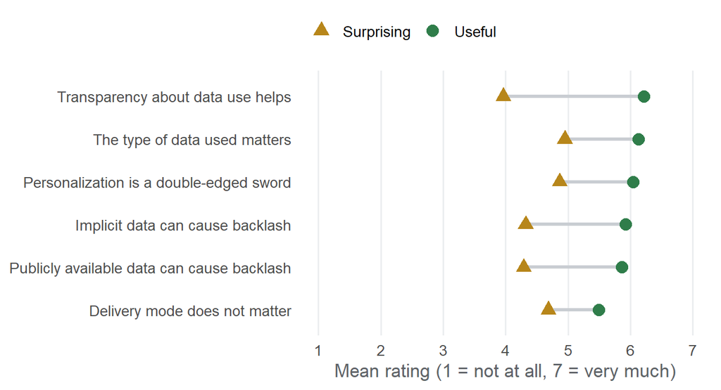

```r
kf_names <- c(KF1 = "Personalization is a double-edged sword", KF2 = "The type of data used matters",
              KF3 = "Implicit data can cause backlash", KF4 = "Publicly available data can cause backlash",
              KF5 = "Transparency about data use helps", KF6 = "Delivery mode does not matter")

means <- survey |>
  summarise(across(ends_with("_c"), ~ mean(.x, na.rm = TRUE))) |>
  pivot_longer(everything(), names_to = c("kf", "rating"), names_pattern = "(KF\\d)_(useful|surprise)_c") |>
  mutate(finding = kf_names[kf], rating = if_else(rating == "useful", "Useful", "Surprising"))
ord <- means |> filter(rating == "Useful") |> arrange(value) |> pull(finding)

means |>
  mutate(finding = factor(finding, levels = ord)) |>
  ggplot(aes(value, finding)) +
  geom_line(aes(group = finding), color = muted, linewidth = 1.2) +
  geom_point(aes(color = rating, shape = rating), size = 3.6) +
  scale_color_manual(values = c(Useful = green, Surprising = gold), name = NULL) +
  scale_shape_manual(values = c(Useful = 16, Surprising = 17), name = NULL) +
  scale_x_continuous(limits = c(1, 7), breaks = 1:7) +
  labs(x = "Mean rating (1 = not at all, 7 = very much)", y = NULL) +
  theme_cep + theme(legend.position = "top", legend.justification = "left")
```

Transparency about data use is the most useful finding and also the least surprising, so the playbook can lead with it as something clients will readily accept.

## Team handoff checklist

- Copy and retain the raw Dataverse files in the documented local folders.
- Render this report once and review the key-field dictionary and range checks.
- Confirm the shared effect-record ID (`IDES`, unique across 2,452 rows).
- Confirm the 289 vs. 290 study and 223 vs. 229 paper counts with Dr. Lin.
- Run the original scripts and reconcile the human baseline with published results.
- Agree on the AO1/AO2 candidate-file contract before creating AI substitutions.
- Run the AO4 search, deduplicate against the anchor list, and start crowd screening.
- Freeze the held-out AI outputs before running the final AO3 comparison.
- Obtain faculty-lead approval for the AO methods and data-preparation plan.

## References

Eisend, M., Niewiadomska, D., & van Noort, G. (2026). Personalization in marketing communication: A meta-analysis. *Journal of Marketing*. https://doi.org/10.1177/00222429261460888

Eisend, M., Niewiadomska, D., & van Noort, G. (2026). *Replication data for: Personalization in marketing communication: A meta-analysis* [Data set]. Harvard Dataverse. https://doi.org/10.7910/DVN/KJRWWM

Landis, J. R., & Koch, G. G. (1977). The measurement of observer agreement for categorical data. *Biometrics, 33*(1), 159–174.

## Appendix

- GitHub Repo: [github.com/gabrielarq1/CEP–Group-8/tree/main/CEP11-Data-Preparation](https://github.com/gabrielarq1/CEP--Group-8/tree/main/CEP11-Data-Preparation)
- GitHub Pages: [gabrielarq1.github.io/CEP–Group-8/CEP11-Data-Preparation/CEP11-Data-Preparation.html](https://gabrielarq1.github.io/CEP--Group-8/CEP11-Data-Preparation/CEP11-Data-Preparation.html)